# Project 3

## Authors:

- Krzysztof Skrobała 156039
- Wojciech Bogacz 156034

```python
from sklearn.linear_model import LogisticRegression
import shap
from sklearn.metrics import accuracy_score, f1_score, roc_auc_score, confusion_matrix, roc_curve, auc
import seaborn as sns
import numpy as np
import pandas as pd

from sklearn.inspection import PartialDependenceDisplay, partial_dependence
import matplotlib.pyplot as plt
from sklearn.model_selection import train_test_split
```

```python
dataset_file = "./data/car evaluation.csv"
df = pd.read_csv(dataset_file, header=None)
df.columns = [
        "buying_price",
        "maintanace_price",
        "number_of_doors",
        "capacity",
        "boot_size",
        "safety",
        "evaluation"
]
classes = ["Unacceptable", "Good"]
```

```python
X = df.drop(columns=["evaluation"])
y = (df["evaluation"] >=2 ).astype(np.uint8)
X_train, X_test, y_train, y_test = train_test_split(X, y, test_size=0.2, random_state=0xC0FFEE)
del X, y
```

```python
model = LogisticRegression()
model.fit(X_train, y_train)
```

```
LogisticRegression()
```

# Report Accuracy, F1 and AUC

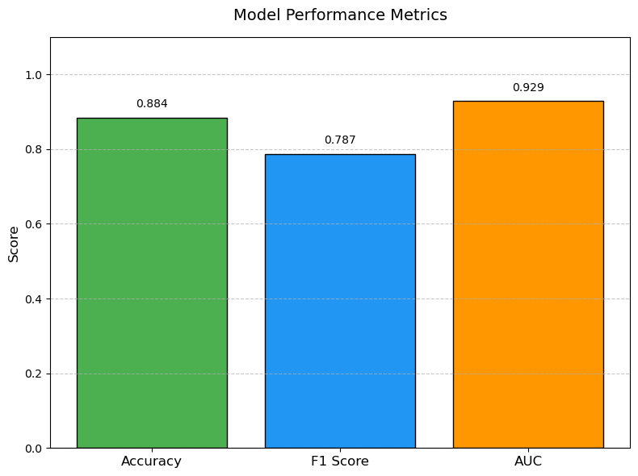

```python
def report_metrics(model, X_test, y_test):
    # Compute metrics
    y_pred = model.predict(X_test)
    accuracy = accuracy_score(y_test, y_pred)
    f1 = f1_score(y_test, y_pred)
    auc = roc_auc_score(y_test, model.predict_proba(X_test)[:, 1])

    metrics = ['Accuracy', 'F1 Score', 'AUC']
    values = [accuracy, f1, auc]

    plt.figure(figsize=(8, 6))
    bars = plt.bar(metrics, values, color=['#4CAF50', '#2196F3', '#FF9800'], edgecolor='black')

    for bar in bars:
        yval = bar.get_height()
        plt.text(bar.get_x() + bar.get_width()/2, yval + 0.02, f'{yval:.3f}',
                 ha='center', va='bottom', fontsize=10)

    plt.title('Model Performance Metrics', fontsize=14, pad=15)
    plt.ylabel('Score', fontsize=12)
    plt.ylim(0, 1.1)  # Extend y-axis for label visibility
    plt.grid(axis='y', linestyle='--', alpha=0.7)
    plt.xticks(fontsize=12)
    plt.yticks(fontsize=10)

    plt.tight_layout()
    plt.show()


report_metrics(model, X_test, y_test)
```

# Models should be presented with all visualizations to facilitate interpretation.

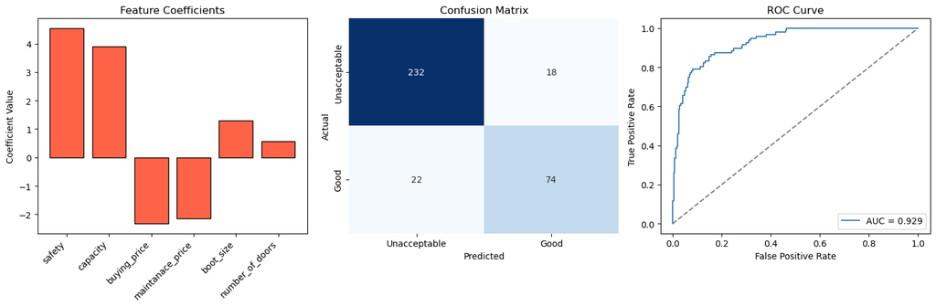

```python
def visualize_model(model, X_test, y_test, feature_names):
    plt.figure(figsize=(15, 5))

    plt.subplot(1, 3, 1)
    coef = model.coef_[0]
    indices = np.argsort(np.abs(coef))[::-1]
    plt.bar(range(len(coef)), coef[indices], color='#FF6347', edgecolor='black')
    plt.xticks(range(len(coef)), [feature_names[i] for i in indices], rotation=45, ha='right')
    plt.title('Feature Coefficients')
    plt.ylabel('Coefficient Value')
    plt.tight_layout()

    plt.subplot(1, 3, 2)
    y_pred = model.predict(X_test)
    cm = confusion_matrix(y_test, y_pred)
    sns.heatmap(cm, annot=True, fmt='d', cmap='Blues', cbar=False)
    plt.title('Confusion Matrix')
    plt.xlabel('Predicted')
    plt.ylabel('Actual')
    plt.xticks([0.5, 1.5], ['Unacceptable', 'Good'])
    plt.yticks([0.5, 1.5], ['Unacceptable', 'Good'])

    plt.subplot(1, 3, 3)
    y_score = model.predict_proba(X_test)[:, 1]
    fpr, tpr, _ = roc_curve(y_test, y_score)
    roc_auc = auc(fpr, tpr)
    plt.plot(fpr, tpr, color='#4682B4', label=f'AUC = {roc_auc:.3f}')
    plt.plot([0, 1], [0, 1], color='gray', linestyle='--')
    plt.title('ROC Curve')
    plt.xlabel('False Positive Rate')
    plt.ylabel('True Positive Rate')
    plt.legend(loc='lower right')

    plt.tight_layout()
    plt.show()

visualize_model(model, X_test, y_test, X_test.columns)
```

# A brief summary taking into account the conclusions of the following analyses

The ROC curve shows strong discriminative ability with an AUC of 0.929, indicating the model effectively separates "Good" and "Unacceptable" classes. An AUC close to 1 (0.929) suggests high reliability in ranking predictions, making the model robust for decision-making in this context.

Depending on the DA goal, we could focus on increasing recall or precision

# Take 3 alternatives and say what the minimum change to a single criterion should be done so that the option is classified into a different class.

```python
def plot_prediction(model, datapoint, feature_names, X_train):
    coef = model.coef_[0]
    intercept = model.intercept_[0]
    x = datapoint

    score = np.dot(coef, x) + intercept
    prob = 1 / (1 + np.exp(-score))
    pred = 1 if prob > 0.5 else 0
    class_label = 'Good' if pred == 1 else 'Unacceptable'

    explainer = shap.Explainer(model, X_train)

    plt.figure(figsize=(15, 5))

    plt.subplot(1, 3, 1)
    plt.bar(feature_names, x, color='#FFB6C1', edgecolor='black')
    plt.title('Attribute Values')
    plt.xticks(rotation=45, ha='right')
    plt.grid(axis='y', linestyle='--', alpha=0.7)

    plt.subplot(1, 3, 2)
    z = np.linspace(-5, 5, 100)
    sigmoid = 1 / (1 + np.exp(-z))
    plt.plot(z, sigmoid, color='#4682B4')
    plt.axhline(y=0.5, color='gray', linestyle='--')
    plt.axvline(x=score, color='red', linestyle='--')
    plt.plot(score, prob, 'ro', markersize=8)
    plt.title('Sigmoid Function')
    plt.xlabel('Logits (z)')
    plt.ylabel('Probability')
    plt.grid(True, linestyle='--', alpha=0.7)



    plt.subplot(1, 3, 3)
    plt.text(0.5, 0.7, f'Logits: {score:.3f}', transform=plt.gca().transAxes, ha='center', bbox=dict(facecolor='lightblue', alpha=0.8))
    plt.text(0.5, 0.5, f'Probability: {prob:.3f}', transform=plt.gca().transAxes, ha='center', bbox=dict(facecolor='lightgreen', alpha=0.8))
    plt.text(0.5, 0.3, f'Predicted Class: {class_label}', transform=plt.gca().transAxes, ha='center', bbox=dict(facecolor='lightyellow', alpha=0.8))
    plt.title('Prediction Details')
    plt.axis('off')

    plt.tight_layout()
    plt.show()

    shap.waterfall_plot(explainer(x.to_frame().T)[0])
    plt.show()
```

```python
def plot_probability_change(model, datapoint, feature_names, feature_idx):
    coef = model.coef_[0]
    intercept = model.intercept_[0]
    x = datapoint.values
    feature_name = feature_names[feature_idx]
    original_value = x[feature_idx]

    x_range = np.linspace(original_value - 5, original_value + 5, 200)
    probs = []

    for val in x_range:
        x_varied = x.copy()
        x_varied[feature_idx] = val
        score = np.dot(coef, x_varied) + intercept
        prob = 1 / (1 + np.exp(-score))
        probs.append(prob)

    threshold_idx = np.argmin(np.abs(np.array(probs) - 0.5))
    threshold_value = x_range[threshold_idx]

    plt.figure(figsize=(10, 6))
    plt.plot(x_range, probs, color='#4682B4', label='Probability')
    plt.axvline(x=original_value, color='green', linestyle='--', label=f'Original {feature_name} = {original_value:.2f}')
    plt.axvline(x=threshold_value, color='red', linestyle='--', label=f'Threshold {feature_name} = {threshold_value:.2f}')
    plt.annotate(f'Distance: {abs(threshold_value - original_value):.2f}',
                 xy=((original_value + threshold_value)/2, 0.5),
                 xytext=((original_value + threshold_value)/2, 0.6),
                 ha='center', va='bottom', color='black')
    plt.title(f'Probability vs {feature_name}')
    plt.xlabel(f'{feature_name} Value')
    plt.ylabel('Probability')
    plt.ylim(0, 1)
    plt.grid(True, linestyle='--', alpha=0.7)
    plt.legend()
    plt.show()
```

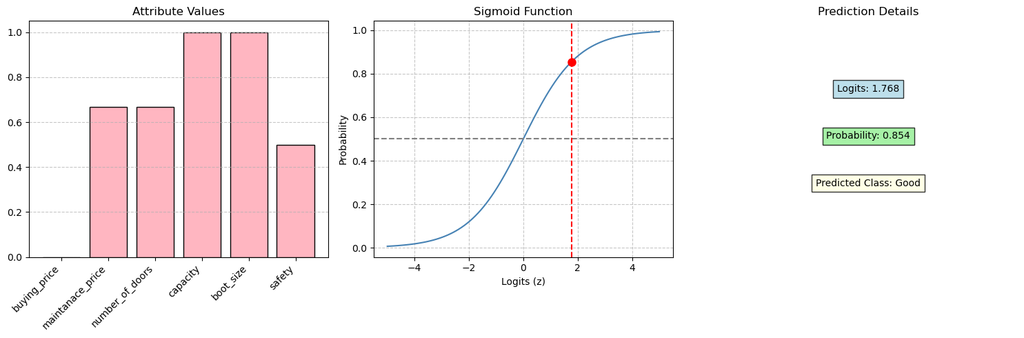

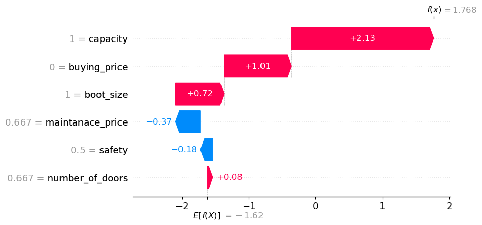

```python
example_1 = X_test.iloc[0,:]
plot_prediction(model, example_1, example_1.index, X_train)
```

### 1. Try to answer this question in an analytical way based only on the values of the model parameters and explain why such a change is minimal (without sampling).

The Logistic Regression assign class acceptable for an alternative $\textbf{x}$ if $\sigma (\textbf w \textbf x^T + b) > 0.5$

From the visualisation we see that the `safety` column has the highest coefficient, and because the weights in Logistic Regression are independent (their influence is independent on other weights) the smallest possible change to change the classification is to change the `safety` attribute

Let's assume $x$ achieved logits $z$

To change its class we have define new attribute vector $x^\star$ where we decrease $x_\text{safety}$ by at least $\Delta x_\text{safety}$ where $z = 0$

$$ \begin{equation} \begin{aligned} \sigma(\textbf w^T \textbf x^\star + b) &= \frac 1 2 \\ \textbf w^T \textbf x^\star + b &= 0 \\ \textbf w^T (\textbf x - \Delta \textbf x) &= -b \\ z - \textbf w^T\Delta \textbf x &= -b \\ -w_\text{safety}\Delta x_\text{safety} &= -b-z\\ \Delta x_\text{safety} &= \frac {b+z} {w_\text{safety}}\\ \end{aligned} \end{equation} $$

To keep in mind is, is that we cannot e.g. lower safety to outside of it domain (it has to be at least 0)

```python
coefs = model.coef_
w_safety = np.max(model.coef_)
intercept = model.intercept_[0]
w_delta = (intercept + np.dot(coefs, example_1)) / w_safety
print(f"To change class, w_safety has to decrease by {w_delta.item():.4f}")
```

```
To change class, w_safety has to decrease by 0.3891
```

### 2. Perform space sampling by slightly changing the evaluations of alternatives to get a different class. Do the results agree with theoretical predictions?

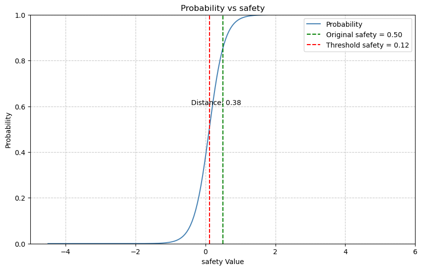

```python
plot_probability_change(model, example_1, example_1.index, example_1.index.to_list().index("safety"))
```

It agrees with the math

# Explain the predictions for these objects using at least one technique (Anchors LIME, SHAP, ... )

From the SHAP waterflow plot (displayed above) we can conclude the following:

The expected logits are -1.62 what means that on average the cars are "Unacceptable", and the values have to increase this likelihood to make car "Good"

For this instance:

### Second example

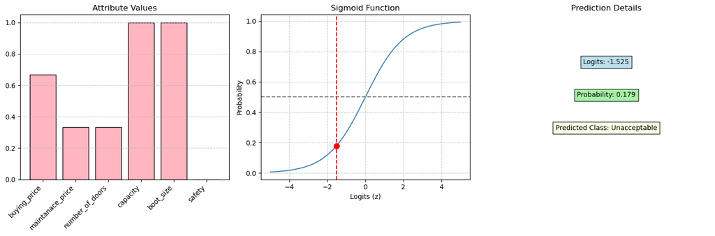

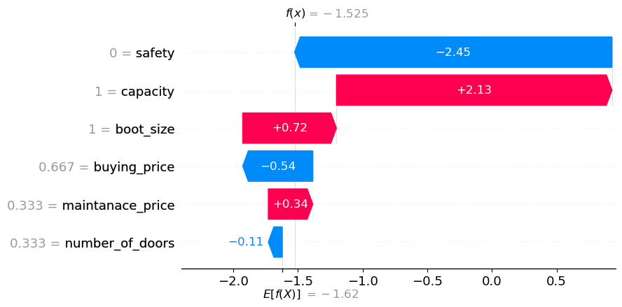

```python
example_2 = X_test.iloc[42,:]
plot_prediction(model, example_2, example_2.index, X_train)
```

```python
coefs = model.coef_
w_safety = np.max(model.coef_)
intercept = model.intercept_[0]
w_delta = (intercept + np.dot(coefs, example_2)) / w_safety
print(f"To change class, w_safety has to decrease by {w_delta.item():.4f}")
```

```
To change class, w_safety has to decrease by -0.3357
```

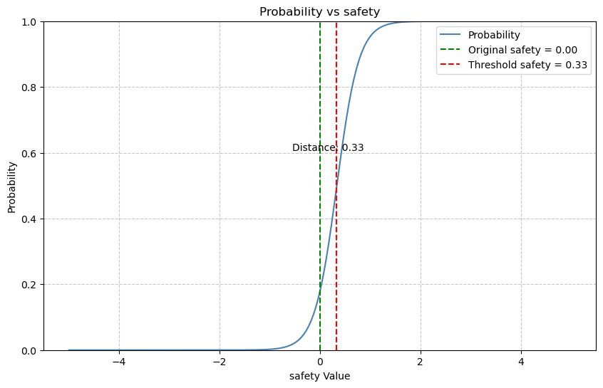

```python
plot_probability_change(model, example_2, example_2.index, example_2.index.to_list().index("safety"))
```

### Third example

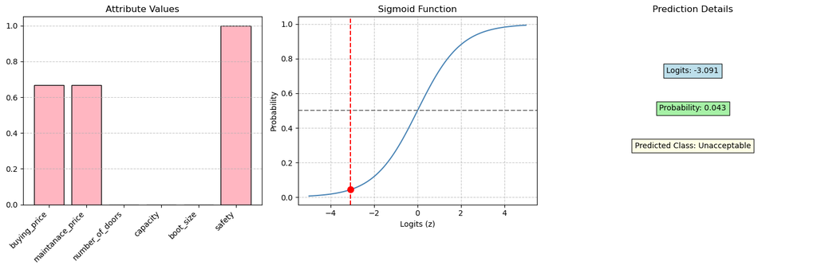

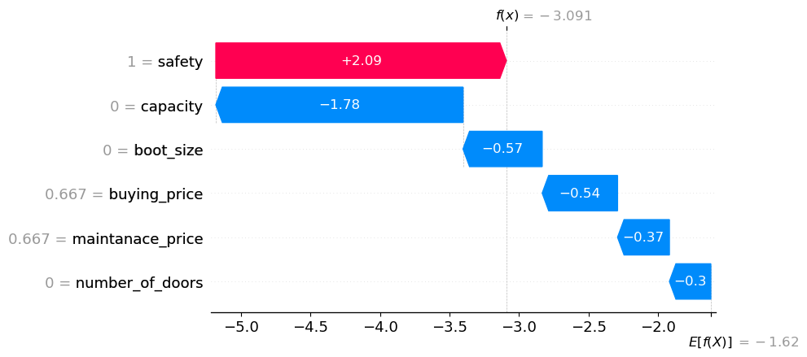

```python
example_3 = X_test.iloc[100,:]
plot_prediction(model, example_3, example_3.index, X_train)
```

```python
coefs = model.coef_
w_safety = np.max(model.coef_)
intercept = model.intercept_[0]
w_delta = (intercept + np.dot(coefs, example_3)) / w_safety
print(f"To change class, w_safety has to decrease by {w_delta.item():.4f}")
```

```
To change class, w_safety has to decrease by -0.6804
```

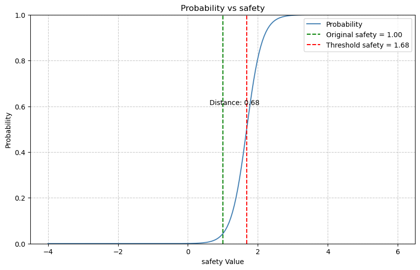

```python
plot_probability_change(model, example_3, example_3.index, example_3.index.to_list().index("safety"))
```

# Based on the parameters obtained, can we say something about the user’s preferences?

# What was the influence of the criteria? Are there any criteria that have no effect, or have a decisive influence?

1. Decisive Influence: capacity and safety.
2. Moderate Influence: boot_size, maintenance_price and buying_price
3. Minimal/No Effect: number_of_doors

# Are there any dependencies between the criteria?

The underlying assumptions of Logistic Regression model is that the features are independent. We could do some feature engineering to tackle this (e.g. adding polynomial combinations) but in the current implementation we cannot examine the depedence (directly from the model), at least in an easy straightforward way.

# What is the nature of the criterion, gain, cost, non-monotonic?

Reading from weights:

1. Gain: capacity, boot_size, safety, number_of_doors
2. Cost: buying price, maintanance_price
3. Non-monotonic: Linear Regression cannot directly model nonmonotonic criterions

# Interpret the model by at least one ( Global Surrogate, Partial Dependence Plot Permutation Feature Importance ...)

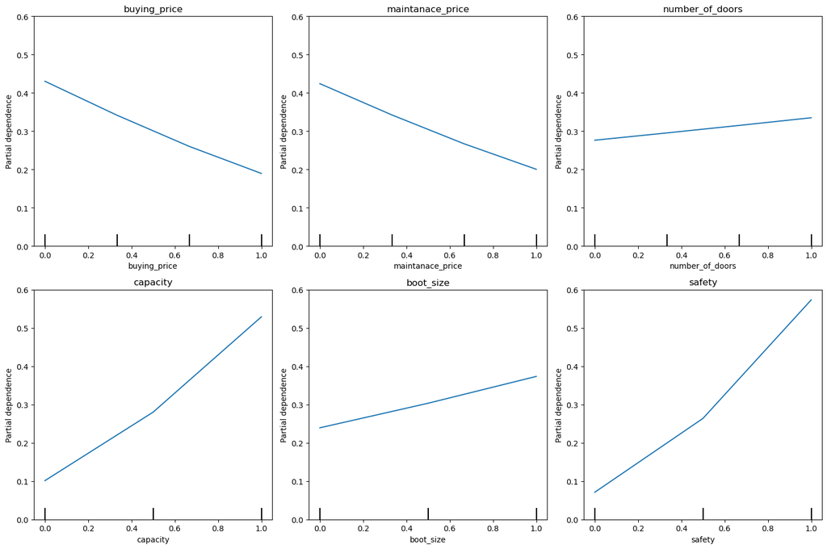

```python
def plot_partial_dependence(model, X_train, feature_names):
    plt.figure(figsize=(15, 10))
    for i in range(len(feature_names)):
        ax = plt.subplot(2, 3, i+1)
        disp = PartialDependenceDisplay.from_estimator(model, X_train, [i], feature_names=feature_names, ax=ax)
        disp.axes_[0].item().set_ylim(0, 0.6)
        plt.title(feature_names[i])
    plt.tight_layout()
    plt.show()

feature_names = ['buying_price', 'maintenance_price', 'number_of_doors', 'capacity', 'boot_size', 'safety']
plot_partial_dependence(model, X_train, X_train.columns)
```

The partial dependency graphs are consistent with our previous answers (e.g. strong upward safety and capacity influence, small influecne of number_of_doors) and comply with the simplicity of the model (monotonicity and no rapid changes)

```python
import numpy as np
    import matplotlib.pyplot as plt
    import torch
    import pandas as pd
    from sklearn.model_selection import train_test_split
    from utils import *
    from uta import Uta
    from norm_layer import NormLayer

    PATH = "uta.pt2"
```

# Data load

```python
path = "data/car evaluation.csv"
    data = pd.read_csv(path, header=None)
    data_1 = data[data.iloc[:, 6] == 1]
    data_1 = data_1.sample(n=400, random_state=1234)
    data_2 = data[data.iloc[:, 6] == 2]
    data_all = pd.concat([data_1, data_2], axis=0)
    data_all = data_all.sample(frac=1, random_state=1234).reset_index(drop=True)

    feature_names = [
        "buying_price",
        "maintanace_price",
        "number_of_doors",
        "capacity",
        "boot_size",
        "safety"
    ]
    class_names = ["unaccetable", "good"]

    target_map = {0: 0, 1: 0, 2: 1, 3: 1, 4: 1}
    num_criteria = 6
    data_input = data_all.iloc[:, :num_criteria]
    data_target = data_all[num_criteria].apply(lambda x: target_map[x])

    data_input = data_input.values.reshape(-1, 1, num_criteria)

    X_train, X_test, y_train, y_test = train_test_split(
        data_input, data_target.values, test_size=0.2, random_state=1234
    )

    train_dataloader = CreateDataLoader(X_train, y_train)
    test_dataloader = CreateDataLoader(X_test, y_test)
```

# Model creation and training

```python
uta = Uta(num_criteria, 30)
    model = NormLayer(uta, num_criteria)
    (
        best_acc,
        best_auc,
        stats_train,
        stats_test,
    ) = Train(model, train_dataloader, test_dataloader, PATH,epoch_nr=300,lr =0.0001,slope_decrease=True)
```

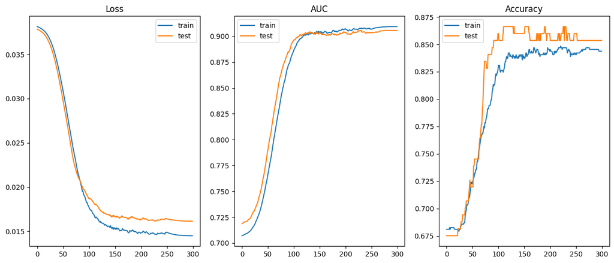

```python
# Plot results
    fig = plt.figure(figsize=(15,6))

    ax = fig.add_subplot(131)
    ax.plot(stats_train.losses,label='train')
    ax.plot(stats_test.losses,label='test')
    ax.set_title('Loss')
    ax.legend()

    ax = fig.add_subplot(1,3,2)
    ax.plot(stats_train.auc_scores,label='train')
    ax.plot(stats_test.auc_scores,label='test')
    ax.set_title('AUC')
    ax.legend()

    ax = fig.add_subplot(1,3,3)
    ax.plot(stats_train.acc_scores,label='train')
    ax.plot(stats_test.acc_scores,label='test')
    ax.set_title('Accuracy')
    ax.legend()
```

# Ploting marginal value functions of best model

```python
# Load model from checkpoint
    checkpoint = torch.load(PATH)
    model.load_state_dict(checkpoint["model_state_dict"])
```

```
<All keys matched successfully>
```

```python
hook = Hook(model.method_instance.monotonic_layer, append_output)
    xs = []
    with torch.no_grad():
        for i in range(201):
            val = i / 200.0
            x = get_simple_input(val,num_criteria)
            xs.append(val)
            model(x)

    outs = np.array(torch.stack(hook.stats)[:, 0].detach().cpu())
    # We take every third value becouse the rest are from the normalization layer: velues for 0 and 1
    outs = outs[::3] - outs[::3][0]
    # Normalize the outputs to get proper weights of the criteria
    outs = outs / outs[-1].sum()
```

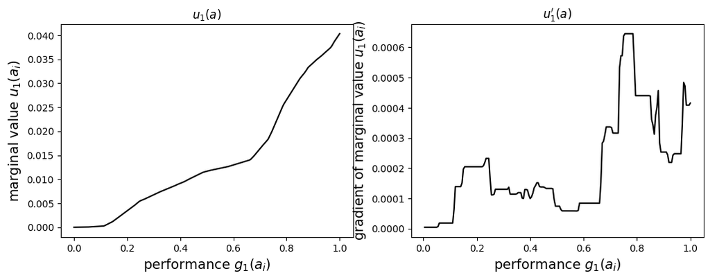

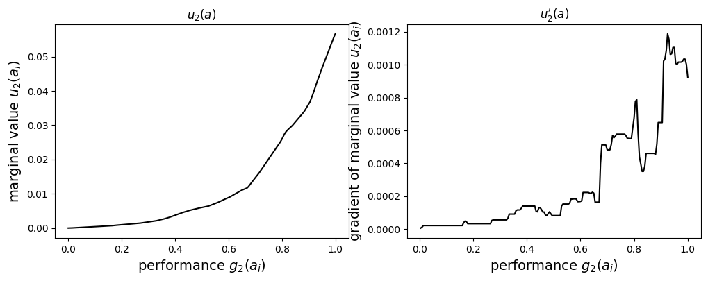

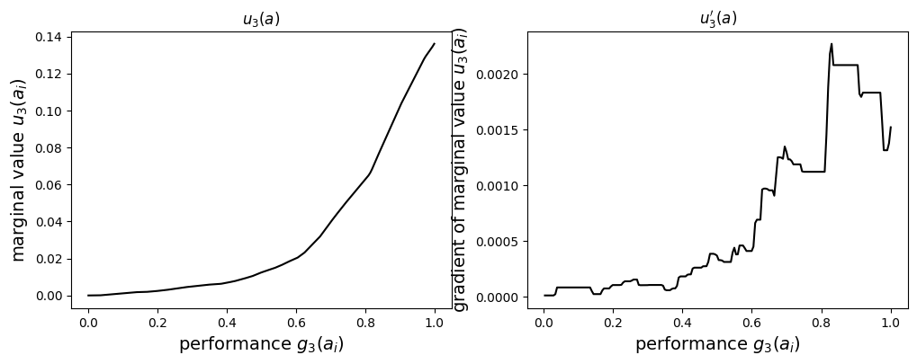

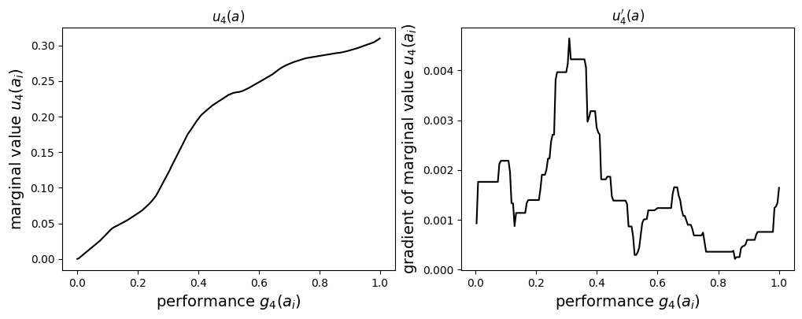

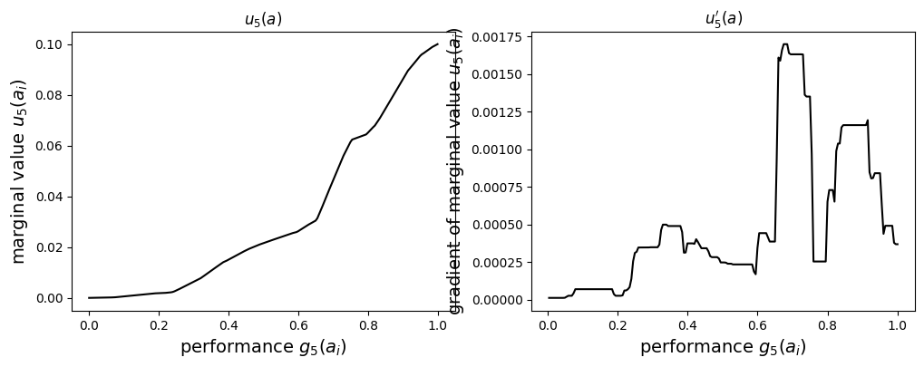

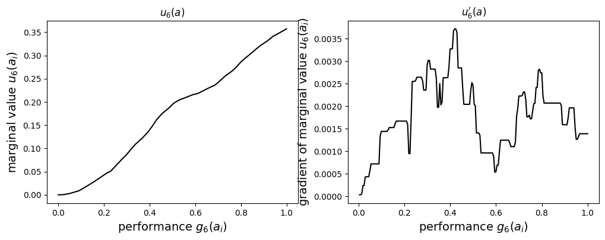

```python
for i in range(num_criteria):
        criterion_number = i + 1
        fig = plt.figure(figsize=(12,4))
        ax = fig.add_subplot(121)
        ax.set_title(f'$u_{criterion_number}(a)$')
        ax.plot(xs, outs[:, i], color="black")
        ax.set_ylabel(f"marginal value $u_{criterion_number}(a_i)$", fontsize=14)
        ax.set_xlabel(f"performance $g_{criterion_number}(a_i)$", fontsize=14)

        ax = fig.add_subplot(1,2,2)
        ax.set_title(f"$u_{criterion_number}'(a)$")
        ax.plot(xs[1:], outs[1:, i]-outs[:-1, i], color="black")
        ax.set_ylabel(f"gradient of marginal value $u_{criterion_number}(a_i)$", fontsize=14)
        ax.set_xlabel(f"performance $g_{criterion_number}(a_i)$", fontsize=14)
        plt.show()
```

```python
from sklearn.metrics import f1_score, accuracy_score, roc_auc_score
    from sklearn.preprocessing import MinMaxScaler

    def f1_score_func(y_true, y_pred):
        return f1_score(y_true, y_pred, average="binary")

    def accuracy_score_func(y_true, y_pred):
        return accuracy_score(y_true, y_pred)

    def roc_auc_score_func(y_true, y_pred):
        return roc_auc_score(y_true, y_pred)


    model.eval()
    with torch.no_grad():
        for x, y in test_dataloader:
            output = model(x)
            # reshape
            arr = output.numpy().reshape(-1, 1)
            scaler = MinMaxScaler()
            output = scaler.fit_transform(arr)
            y_pred = (output > 0.5)
            y_true = y.numpy()


            print(f"F1 score: {f1_score_func(y_true, y_pred):.4f}")
            print(f"Accuracy score: {accuracy_score_func(y_true, y_pred):.4f}")
            print(f"ROC AUC score: {roc_auc_score_func(y_true, y_pred):.4f}")
```

```
F1 score: 0.8659
    Accuracy score: 0.8599
    ROC AUC score: 0.8636
```

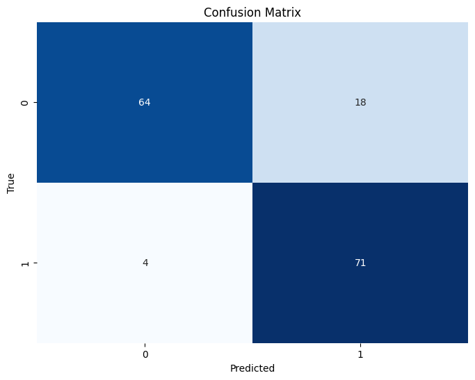

```
Precision score: 0.7978
    Recall score: 0.9467
```

```python
from sklearn.metrics import confusion_matrix, precision_score, recall_score
    import matplotlib.pyplot as plt
    import seaborn as sns

    def precision_score_func(y_true, y_pred):
        return precision_score(y_true, y_pred, average="binary")

    def recall_score_func(y_true, y_pred):
        return recall_score(y_true, y_pred, average="binary")


    def plot_confusion_matrix(y_true, y_pred):
        cm = confusion_matrix(y_true, y_pred)
        plt.figure(figsize=(8, 6))
        sns.heatmap(cm, annot=True, fmt="d", cmap="Blues", cbar=False)
        plt.xlabel("Predicted")
        plt.ylabel("True")
        plt.title("Confusion Matrix")
        plt.show()

    plot_confusion_matrix(y_true, y_pred)

    print(f"Precision score: {precision_score_func(y_true, y_pred):.4f}")
    print(f"Recall score: {recall_score_func(y_true, y_pred):.4f}")
```

### Brief Summary

The model achived F1, Accuracy and ROC AUC scores around 0.85 which shows that the model effectively separates Good and Unacceptable classes. However, probably some optimization could be apply to even more increase the metrics.

Plots of the marginal value functions and plots of the gradients of marginal value functions show which values for specyfic criterion are important in case of predictions.

Last but not least, Confusion Matrix clarifies for which class the model makes more errors. As a result, the output of the model should be properly interpreted.

## Explanation of the decisions

```python
alternative_1_pred = y_pred[5].copy()
    alternative_2_pred = y_pred[12].copy()
    alternative_3_pred = y_pred[35].copy()

    alternative_1 = data_input[5].copy()
    alternative_2 = data_input[12].copy()
    alternative_3 = data_input[35].copy()

    print("Alternative 1 prediction: ", alternative_1_pred)
    print("Alternative 1: ", alternative_1)
    print("Alternative 2 prediction: ", alternative_2_pred)
    print("Alternative 2: ", alternative_2)
    print("Alternative 3 prediction: ", alternative_3_pred)
    print("Alternative 3: ", alternative_3)
```

```
Alternative 1 prediction:  [False]
    Alternative 1:  [[1.       0.       0.333333 0.5      0.5      0.5     ]]
    Alternative 2 prediction:  [ True]
    Alternative 2:  [[0.666667 0.333333 1.       0.5      0.5      1.      ]]
    Alternative 3 prediction:  [False]
    Alternative 3:  [[0.333333 0.333333 0.333333 0.       0.5      0.      ]]
```

```python
feature_names = [
        "buying_price",
        "maintanace_price",
        "number_of_doors",
        "capacity",
        "boot_size",
        "safety"
    ]
    class_names = ["unaccetable", "good"]
```

We can analyze possible change of the prediction based on the gradients of the marginal value functions. For first 3 criteria: buying_price, maintanace_price, number_of_doors it can be noticed that around 0.8 value the gradient drastically rised therefore this value might be significant in terms of changeing the prediction. On the other hand, criteria capacity and safety have the most significant values around 0.4. The boot_size criterion has the most important value around 0.7.

```python
def test_model(model, test_dataset):
        data_test = test_dataset.reshape(-1, num_criteria)
        data_test_target = np.array([data_target[5], data_target[12], data_target[35]])
        data_test_target = data_test_target.reshape(-1, 1)

        data_set = CreateDataLoader(data_test, data_test_target)

        model.eval()
        with torch.no_grad():
            for x, y in data_set:
                output = model(x)
                y_pred_alt = (output > 0.0)
        return y_pred_alt
```

```python
print(alternative_1)
    print(alternative_2)
    print(alternative_3)

    data_test = np.concatenate((alternative_1, alternative_2, alternative_3), axis=0)
    y_pred_alt = test_model(model, data_test)
    print(y_pred_alt)


    # Let's change the values of the alternatives and check the predictions
    alternative_1[0][1] += 0.8


    alternative_2[0][1] -= 0.6
    alternative_2[0][2] -= 0.6
    alternative_2[0][5] -= 0.6




    alternative_3[0][3] += 0.6
    alternative_3[0][5] += 0.8

    print(alternative_1)
    print(alternative_2)
    print(alternative_3)
    data_test = np.concatenate((alternative_1, alternative_2, alternative_3), axis=0)
    y_pred_alt = test_model(model, data_test)

    print(y_pred_alt)
```

```
[[1.       0.       0.333333 0.5      0.5      0.5     ]]
    [[0.666667 0.333333 1.       0.5      0.5      1.      ]]
    [[0.333333 0.333333 0.333333 0.       0.5      0.      ]]
    tensor([False,  True, False])
    [[1.       0.8      0.333333 0.5      0.5      0.5     ]]
    [[ 0.666667 -0.266667  0.4       0.5       0.5       0.4     ]]
    [[0.333333 0.333333 0.333333 0.6      0.5      0.8     ]]
    tensor([ True, False,  True])
```

```python
def predict(alternatives):
        alternatives = torch.tensor(alternatives, dtype=torch.float32)

        model.eval()
        with torch.no_grad():
            output = model(alternatives)
            output = output.reshape(output.shape[0],1)
            probabilities = torch.sigmoid(output).numpy()

        return np.hstack([1 - probabilities, probabilities])
```

```
Predicted probabilities: [[0.50642425 0.49357575]
     [0.43939203 0.56060797]
     [0.6180163  0.3819837 ]]
```

```
[1.       0.       0.333333 0.5      0.5      0.5     ]
    tensor([False])
    [('0.25 < capacity <= 0.50', 0.05658559075756969), ('number_of_doors <= 0.33', -0.03311268292230659), ('buying_price > 0.83', 0.008453102598868086), ('0.25 < safety <= 0.50', 0.005907160320215614), ('maintanace_price <= 0.17', -0.002853934611509495), ('boot_size <= 0.50', 0.0)]
```

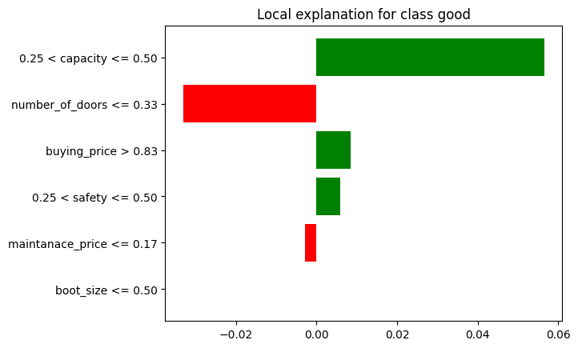

```python
import lime
    import lime.lime_tabular

    alternative_1 = data_input[5].copy()
    alternative_2 = data_input[12].copy()
    alternative_3 = data_input[35].copy()

    data_test = np.concatenate((alternative_1, alternative_2, alternative_3), axis=0)
    predicted_probs = predict(data_test)

    print("Predicted probabilities:", predicted_probs)

    explainer = lime.lime_tabular.LimeTabularExplainer(
        class_names=class_names,
        feature_names=feature_names,
        training_data=data_test
    )


    exp = explainer.explain_instance(
        data_row=data_test[0],
        predict_fn=predict,
        num_features=6
    )
    print(data_test[0])
    print(test_model(model, data_test[0]))

    print(exp.as_list())
    import matplotlib.pyplot as plt

    fig = exp.as_pyplot_figure()
    plt.show()
```

```
tensor([True])
    [('safety > 0.75', 0.06413277349376872), ('0.25 < capacity <= 0.50', 0.057323327210431645), ('number_of_doors > 0.67', 0.033854429122366116), ('0.50 < buying_price <= 0.67', -0.001902694201822782), ('0.17 < maintanace_price <= 0.33', 0.0008866821241344642), ('boot_size <= 0.50', 0.0)]
```

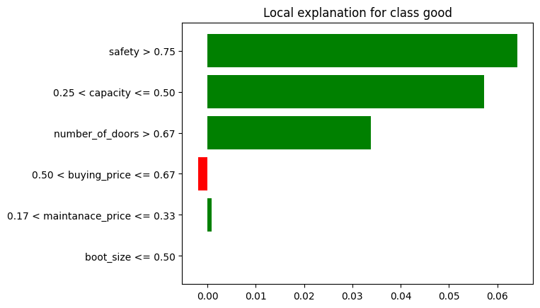

```python
exp = explainer.explain_instance(
        data_row=data_test[1],
        predict_fn=predict,
        num_features=6
    )
    print(test_model(model, data_test[1]))

    print(exp.as_list())
    fig = exp.as_pyplot_figure()
    plt.show()
```

This alternative is classified as good, therefore most of the features have positive impact on class good.

```
tensor([False])
    [('safety <= 0.25', -0.06845327810877222), ('capacity <= 0.25', -0.05617231666611182), ('number_of_doors <= 0.33', -0.033869422231894944), ('buying_price <= 0.50', -0.00494170754751604), ('0.17 < maintanace_price <= 0.33', 0.0007139700756291917), ('boot_size <= 0.50', 0.0)]
```

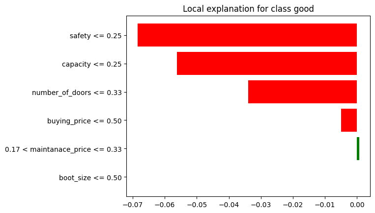

```python
exp = explainer.explain_instance(
        data_row=data_test[2],
        predict_fn=predict,
        num_features=6
    )
    print(test_model(model, data_test[2]))

    print(exp.as_list())
    fig = exp.as_pyplot_figure()
    plt.show()
```

This alternative is classfied as unacceptable. of the features ahve negative imapct on good class, therefore it cen be said that this alternative is strongly unacceptable by the model.

## Interpretation of the model

```python
feature_names = [
        "buying_price",
        "maintanace_price",
        "number_of_doors",
        "capacity",
        "boot_size",
        "safety"
    ]
    class_names = ["unaccetable", "good"]
```

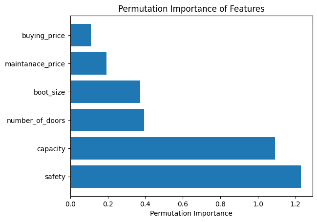

```python
from sklearn.inspection import permutation_importance


    def predict_fn(alternatives):
        alternatives = torch.tensor(alternatives, dtype=torch.float32)

        model.eval()
        with torch.no_grad():
            output = model(alternatives)
            arr = output.numpy().reshape(-1, 1)
            scaler = MinMaxScaler()
            output = scaler.fit_transform(arr)
            y_pred = (output > 0.5)

        return y_pred


    class SklearnWrapper:
        def __init__(self, predict_fn):
            self.predict_fn = predict_fn

        def predict(self, X):
            return self.predict_fn(X)

        def fit(self, X, y=None):
            return self


    data_test = X_train.reshape(-1, num_criteria)

    model_wrapper = SklearnWrapper(predict_fn)
    result = permutation_importance(
        model_wrapper,
        data_test,
        predict_fn(data_test),
        scoring='r2',
        n_repeats=10,
        random_state=42,
        n_jobs=-1
    )


    sorted_result = result.importances_mean.argsort()[::-1]
    plt.barh(range(len(sorted_result)), result.importances_mean[sorted_result], align="center")
    plt.yticks(range(len(sorted_result)), np.array(feature_names)[sorted_result])
    plt.xlabel("Permutation Importance")
    plt.title("Permutation Importance of Features")
    plt.show()
```